# 07_Embedding_Physical_Knowledge_Lab_textbook

**Scientific Machine Learning:**  
**Embedding Prior Knowledge into Neural Networks: Labs**

These laboratory problems accompany the discussion of embedding prior knowledge into neural networks. Three compact examples are treated, each one an application in which the required behavior is known before any data is seen.

| Lab | Application | Prior knowledge | Embedding route |
| --- | --- | --- | --- |
| 1 | Drug concentration | Positive, non-increasing, known initial value | Loss penalty + hard parameterization |
| 2 | Epidemic compartments | Positive fractions and total population = 1 | Loss penalty + projection + Softmax |
| 3 | Pairwise interaction | Translation, rotation, and permutation symmetry | Augmentation + pooling + invariant feature |

All three follow the same workflow: state the prior knowledge, train alternative models that embed it in different places, apply the required transformations, and verify the behavior directly from the outputs.

## Learning Objectives

After studying this notebook, you should be able to

- name the places in a neural-network pipeline where prior knowledge can enter — the data, the input features, the loss, the output transformation, a post-processing step, and differentiation of the output — and say what each one guarantees;
- impose a requirement softly by adding its violation to the loss, and state why such a penalty discourages a violation without preventing it;
- impose the same requirement exactly by construction, writing a positive, monotone decreasing curve as an exponential of an integrated positive rate, and nonnegative fractions summing to one as a Softmax output;
- correct a linear equality after prediction by projection, and explain why projection fixes the sum but not the sign;
- compare a hard construction against a soft penalty on the same data and read the resulting trade-off between guaranteed behavior and data error;
- encode a symmetry by data augmentation, by averaging predictions over a finite transformation group, and by replacing the coordinates with an invariant feature, and distinguish invariance from predictive accuracy;
- obtain an equivariant vector field by differentiating an invariant scalar, and verify the relation numerically.
1. Drug Concentration: Soft and Hard Constraints
   1. Sparse Noisy Data
   2. Baseline and Soft Enforcement
   3. Hard Enforcement with a Positive Rate
   4. Comparing Predictions and Constraint Behavior
2. Epidemic Compartments: Conservation and Projection
   1. Reference SIR Data
   2. Three Embedding Routes
   3. Training the Baseline, Soft, and Hard Models
   4. Projection and Output Transformations
   5. Comparing Predictions and Conservation
3. Pairwise Interaction: Invariance and Equivariance
   1. Pairwise Interaction Data
   2. Four Symmetry Strategies
   3. Training the Symmetry Strategies
   4. Equivalent Configurations
   5. From Invariant Energy to Equivariant Force

Summary

# 1. Drug Concentration: Soft and Hard Constraints

> **Question:** can a neural network fit noisy measurements while preserving physically valid concentration behavior?

| Item | Definition |
| --- | --- |
| Input | Time $t$ |
| Output | Drug concentration $C(t)$ |
| Prior knowledge | $C(t)\ge0$, $dC/dt\le0$, and $C(0)=C_0$ |
| Comparison | Baseline vs. soft penalty vs. hard parameterization |

After a single dose, concentration should remain nonnegative, decrease over time, and begin from the known initial value:

$$ C(t)\ge0, \qquad \frac{dC}{dt}\le0, \qquad C(0)=C_0. $$

**Setup**

Libraries and random seeds, fixed once for all three laboratories. Everything else is written out where it is used: each section builds its own network, writes its own training loop and draws its own figures, so that no part of a laboratory problem is hidden in a helper defined elsewhere.

```python
import numpy as np
import torch
import torch.nn as nn
import matplotlib.pyplot as plt

np.random.seed(7)
torch.manual_seed(7)
```

```
<torch._C.Generator at 0x7a0cc6537610>
```

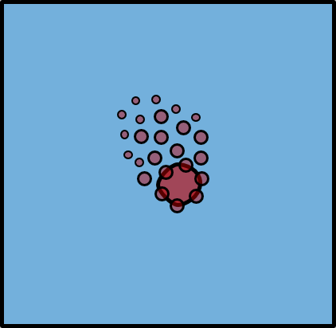

## 1.1. Sparse Noisy Data

Twelve noisy measurements of a decaying concentration, one of them an outlier and the last one negative: a record on which a fit that knows nothing about the physics can go wrong in exactly the ways the prior knowledge forbids.

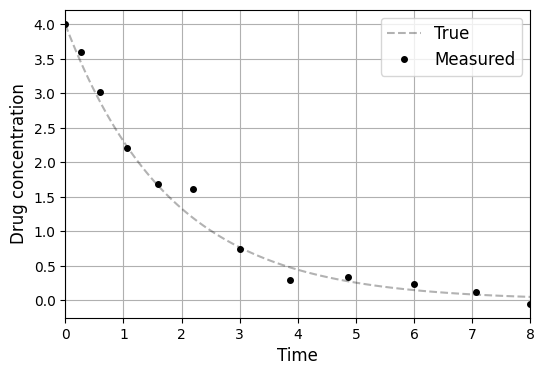

```python
t = np.linspace(0, 8, 121).reshape(-1, 1)      # time grid
C0 = 4.0                                       # initial concentration
C_true = C0*np.exp(-0.55*t)                    # reference curve

# 12 noisy measurements taken at these grid points
idx = np.array([0, 4, 9, 16, 24, 33, 45, 58, 73, 90, 106, 120])

t_obs = t[idx]
C_obs = C_true[idx] + 0.10*np.random.randn(len(idx), 1)
C_obs[5] = C_obs[5] + 0.35                     # one outlier
C_obs[-1] = -0.05                              # one negative measurement

plt.figure(figsize = (6, 4))
plt.plot(t, C_true, 'k--', alpha = 0.3)
plt.plot(t_obs, C_obs, 'ko', markersize = 4)
plt.xlim([0, 8])
plt.xlabel('Time', fontsize = 12)
plt.ylabel('Drug concentration', fontsize = 12)
plt.legend(['True', 'Measured'], fontsize = 12)
plt.grid(True)
plt.show()
```

```python
# the network input is the time rescaled to [-1, 1]

x = (t - 4)/4

x_all = torch.tensor(x, dtype = torch.float32)
x_obs = torch.tensor(x[idx], dtype = torch.float32)
y_obs = torch.tensor(C_obs, dtype = torch.float32)
```

## 1.2. Baseline and Soft Enforcement

The baseline minimizes data error only. The soft model additionally penalizes negative concentration, positive slope, and initial-condition error:

$$ \mathcal{L}_{\mathrm{soft}} =\mathcal{L}_{\mathrm{data}} +\lambda_{+}\operatorname{ReLU}(-C)^2 +\lambda_m\operatorname{ReLU}\!\left(\frac{dC}{dt}\right)^2 +\lambda_0\left(C(0)-C_0\right)^2. $$

Soft enforcement discourages violations but does not make them impossible.

```python
# baseline: data error only

base = nn.Sequential(nn.Linear(1, 32), nn.Tanh(),
                     nn.Linear(32, 32), nn.Tanh(),
                     nn.Linear(32, 1))

optm = torch.optim.Adam(base.parameters(), lr = 0.002)

for epoch in range(1800):
    loss = torch.mean((base(x_obs) - y_obs)**2)

    optm.zero_grad()
    loss.backward()
    optm.step()

print('baseline data loss = %.3e' % loss.item())

C_base = base(x_all).detach().numpy()
```

```
baseline data loss = 9.341e-03
```

```python
# soft: data error + three penalties

soft = nn.Sequential(nn.Linear(1, 32), nn.Tanh(),
                     nn.Linear(32, 32), nn.Tanh(),
                     nn.Linear(32, 1))

optm = torch.optim.Adam(soft.parameters(), lr = 0.002)

x_check = x_all.clone().requires_grad_(True)   # where the constraints are checked
x_zero = torch.tensor([[-1.0]])                # input that corresponds to t = 0

for epoch in range(1800):
    C = soft(x_check)
    dC = torch.autograd.grad(C, x_check, torch.ones_like(C), create_graph = True)[0]

    data_loss = torch.mean((soft(x_obs) - y_obs)**2)
    positive_loss = torch.mean(torch.relu(-C)**2)        # active when C < 0
    decrease_loss = torch.mean(torch.relu(dC)**2)        # active when C increases
    initial_loss = torch.mean((soft(x_zero) - C0)**2)    # active when C(0) != C0

    loss = data_loss + 20*positive_loss + 20*decrease_loss + 10*initial_loss

    optm.zero_grad()
    loss.backward()
    optm.step()

print('soft total loss = %.3e' % loss.item())

C_soft = soft(x_all).detach().numpy()
```

```
soft total loss = 2.209e-02
```

## 1.3. Hard Enforcement with a Positive Rate

The network predicts a positive elimination rate and integrates it into the concentration:

$$ r_\theta(t)=\operatorname{Softplus}(z_\theta(t))>0, $$

$$ C(t)=C_0\exp\left[-\int_0^t r_\theta(\tau)\,d\tau\right]. $$

This form guarantees positivity, monotone decrease, and the initial value. A small rate-smoothness penalty prevents unrealistically sharp decay, producing a **hybrid constraint**: hard validity with soft regularization.

```python
# hard: the network predicts a positive rate, the curve is built from it

hard = nn.Sequential(nn.Linear(1, 32), nn.Tanh(),
                     nn.Linear(32, 32), nn.Tanh(),
                     nn.Linear(32, 1))

optm = torch.optim.Adam(hard.parameters(), lr = 0.002)

t_torch = torch.tensor(t, dtype = torch.float32)
dt = t_torch[1:] - t_torch[:-1]
zero = torch.zeros(1, 1)

for epoch in range(1800):
    rate = torch.log(1 + torch.exp(hard(x_all)))         # softplus keeps the rate positive

    area = 0.5*(rate[1:] + rate[:-1])*dt                 # trapezoid area of each interval
    integral = torch.cat([zero, torch.cumsum(area, 0)])  # integral of the rate up to each time
    C = C0*torch.exp(-integral)                          # positive and decreasing by construction

    data_loss = torch.mean((C[idx] - y_obs)**2)
    smooth_loss = torch.mean((rate[1:] - rate[:-1])**2)  # keeps the rate from changing too fast

    loss = data_loss + 100*smooth_loss

    optm.zero_grad()
    loss.backward()
    optm.step()

print('hard total loss = %.3e' % loss.item())

C_hard = C.detach().numpy()
```

```
hard total loss = 1.617e-02
```

## 1.4. Comparing Predictions and Constraint Behavior

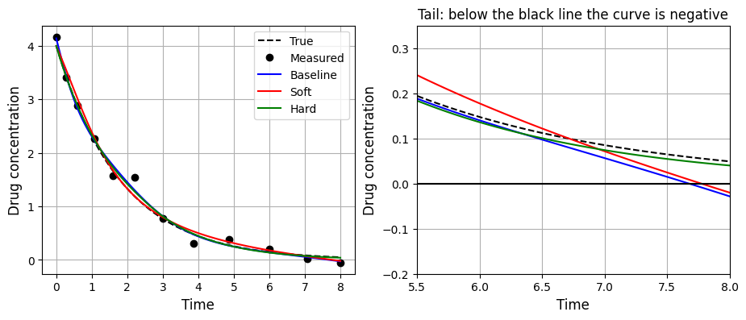

```python
plt.figure(figsize = (11, 4))

plt.subplot(1, 2, 1)
plt.plot(t, C_true, 'k--')
plt.plot(t_obs, C_obs, 'ko')
plt.plot(t, C_base, 'b')
plt.plot(t, C_soft, 'r')
plt.plot(t, C_hard, 'g')
plt.xlabel('Time', fontsize = 12)
plt.ylabel('Drug concentration', fontsize = 12)
plt.legend(['True', 'Measured', 'Baseline', 'Soft', 'Hard'], fontsize = 10)
plt.grid(True)

plt.subplot(1, 2, 2)                                     # zoom on the tail
plt.plot(t, C_true, 'k--')
plt.plot(t, C_base, 'b')
plt.plot(t, C_soft, 'r')
plt.plot(t, C_hard, 'g')
plt.plot(t, 0*t, 'k')
plt.xlim(5.5, 8)
plt.ylim(-0.2, 0.35)
plt.xlabel('Time', fontsize = 12)
plt.ylabel('Drug concentration', fontsize = 12)
plt.title('Tail: below the black line the curve is negative', fontsize = 12)
plt.grid(True)

plt.show()
```

### 1.4.1. Numerical Check

```python
print('model      negative  increasing  IC error  RMSE')

for name, C in [('baseline', C_base), ('soft', C_soft), ('hard', C_hard)]:
    negative = np.sum(C < 0)                             # how many points fall below zero
    increasing = np.sum(np.diff(C[:, 0]) > 1e-4)         # how many steps go up
    ic_error = abs(C[0, 0] - C0)                         # error at t = 0
    rmse = np.sqrt(np.mean((C - C_true)**2))             # error against the true curve

    print('%-10s %8d %11d %9.3f %5.3f' % (name, negative, increasing, ic_error, rmse))
```

```
model      negative  increasing  IC error  RMSE
baseline          5           0     0.142 0.055
soft              4           0     0.001 0.055
hard              0           0     0.000 0.037
```

### 1.4.2. Interpretation

- **Baseline:** follows the observations without any validity guarantee.
- **Soft:** reduces violations, but a small negative prediction can remain.
- **Hard:** stays nonnegative, decreases monotonically, and satisfies $C(0)=C_0$ by construction.

> **Key point:** hard constraints guarantee the prescribed behavior, not the smallest data error. If the prior knowledge is incorrect or too restrictive, prediction accuracy can decrease.

# 2. Epidemic Compartments: Conservation and Projection

> **Question:** how can a neural network keep population fractions valid at every time?

| Item | Definition |
| --- | --- |
| Input | Time $t$ |
| Output | Susceptible $S$, infected $I$, recovered $R$ |
| Prior knowledge | Nonnegative fractions and $S+I+R=1$ |
| Comparison | Soft penalty vs. projection vs. Softmax |

Every person belongs to one compartment, so the constraints must hold locally at every time:

$$ S(t),I(t),R(t)\ge0, \qquad S(t)+I(t)+R(t)=1. $$

[figure not shown]

## 2.1. Reference SIR Data

The reference curves are the SIR equations integrated numerically, and seventeen noisy measurements of the three fractions are drawn from them. The noise is what makes the sum and the signs of the predictions uncertain.

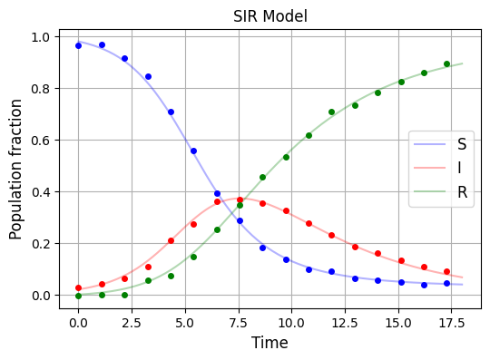

```python
beta = 0.9                                     # infection rate
gamma = 0.25                                   # recovery rate

dt = 0.01
n = 1801

S = np.zeros(n)
I = np.zeros(n)
R = np.zeros(n)

S[0] = 0.98
I[0] = 0.02
R[0] = 0.00

for k in range(n - 1):                         # explicit Euler steps
    infection = beta*S[k]*I[k]
    recovery = gamma*I[k]

    S[k+1] = S[k] - dt*infection
    I[k+1] = I[k] + dt*(infection - recovery)
    R[k+1] = R[k] + dt*recovery

sub = np.arange(0, n, 12)                      # keep every 12th point

t2 = dt*sub
Y = np.column_stack([S[sub], I[sub], R[sub]])

obs = np.arange(0, 151, 9)                     # 17 noisy measurements
Y_obs = Y[obs] + 0.012*np.random.randn(len(obs), 3)

plt.figure(figsize = (6, 4))
plt.plot(t2, Y[:, 0], 'b', t2, Y[:, 1], 'r', t2, Y[:, 2], 'g', alpha = 0.3)
plt.plot(t2[obs], Y_obs[:, 0], 'bo', t2[obs], Y_obs[:, 1], 'ro', t2[obs], Y_obs[:, 2], 'go', markersize = 4)
plt.title('SIR Model', fontsize = 12)
plt.xlabel('Time', fontsize = 12)
plt.ylabel('Population fraction', fontsize = 12)
plt.legend(['S', 'I', 'R'], fontsize = 12)
plt.grid(True)
plt.show()
```

```python
x2 = torch.tensor((t2.reshape(-1, 1) - 9)/9, dtype = torch.float32)
x2_obs = x2[obs]
y2_obs = torch.tensor(Y_obs, dtype = torch.float32)
```

## 2.2. Three Embedding Routes

| Method | Implementation | Guaranteed behavior |
| --- | --- | --- |
| Soft | Add violations to the loss | Approximate positivity and conservation |
| Projection | Correct the raw output after prediction | Exact sum only |
| Hard | Apply Softmax to network logits | Exact positivity and sum |

### 2.2.1. Soft: Loss Penalty

$$ \mathcal{L}=\mathcal{L}_{data} +\lambda_c(\hat S+\hat I+\hat R-1)^2 +\lambda_p\sum_{k\in\{S,I,R\}}\operatorname{ReLU}(-\hat y_k)^2. $$

### 2.2.2. Projection: Output Correction

$$ \hat{\mathbf y}_{proj} =\hat{\mathbf y} +\frac{1-(\hat S+\hat I+\hat R)}{3}[1,1,1]. $$

Projection requires no additional training and guarantees $\hat S_{proj}+\hat I_{proj}+\hat R_{proj}=1$, but negative fractions may remain.

### 2.2.3. Hard: Softmax Output

$$ \hat y_k=\frac{\exp(z_k)}{\exp(z_S)+\exp(z_I)+\exp(z_R)}. $$

Softmax guarantees $\hat S,\hat I,\hat R>0$ and $\hat S+\hat I+\hat R=1$ simultaneously.

## 2.3. Training the Baseline, Soft, and Hard Models

The three models fit the same seventeen measurements and differ only in where the prior knowledge enters: nowhere, in the loss, or in the output.

```python
# baseline: data error only

base2 = nn.Sequential(nn.Linear(1, 32), nn.Tanh(),
                      nn.Linear(32, 32), nn.Tanh(),
                      nn.Linear(32, 3))

optm = torch.optim.Adam(base2.parameters(), lr = 0.002)

for epoch in range(1800):
    loss = torch.mean((base2(x2_obs) - y2_obs)**2)

    optm.zero_grad()
    loss.backward()
    optm.step()

print('baseline loss = %.3e' % loss.item())
```

```
baseline loss = 5.627e-05
```

```python
# soft: data error + conservation penalty + positivity penalty

soft2 = nn.Sequential(nn.Linear(1, 32), nn.Tanh(),
                      nn.Linear(32, 32), nn.Tanh(),
                      nn.Linear(32, 3))

optm = torch.optim.Adam(soft2.parameters(), lr = 0.002)

for epoch in range(1800):
    P = soft2(x2)

    data_loss = torch.mean((soft2(x2_obs) - y2_obs)**2)
    sum_loss = torch.mean((torch.sum(P, 1) - 1)**2)      # active when S + I + R != 1
    positive_loss = torch.mean(torch.relu(-P)**2)        # active when a fraction is negative

    loss = data_loss + 10*sum_loss + 10*positive_loss

    optm.zero_grad()
    loss.backward()
    optm.step()

print('soft loss = %.3e' % loss.item())
```

```
soft loss = 1.979e-04
```

```python
# hard: the three outputs pass through a softmax

hard2 = nn.Sequential(nn.Linear(1, 32), nn.Tanh(),
                      nn.Linear(32, 32), nn.Tanh(),
                      nn.Linear(32, 3))

optm = torch.optim.Adam(hard2.parameters(), lr = 0.002)

for epoch in range(1800):
    P = torch.softmax(hard2(x2_obs), 1)

    loss = torch.mean((P - y2_obs)**2)

    optm.zero_grad()
    loss.backward()
    optm.step()

print('hard loss = %.3e' % loss.item())
```

```
hard loss = 7.202e-05
```

## 2.4. Projection and Output Transformations

Projection is applied to the baseline after training, with no further learning; the sum at $t = 0$ shows the correction being exact.

```python
with torch.no_grad():
    P_base = base2(x2).numpy()
    P_soft = soft2(x2).numpy()
    P_hard = torch.softmax(hard2(x2), 1).numpy()

# projection: shift the three raw outputs so that they sum to one

shift = (1 - np.sum(P_base, 1))/3

P_proj = P_base + shift.reshape(-1, 1)

print('sum before projection at t = 0: %.4f' % np.sum(P_base[0]))
print('sum after  projection at t = 0: %.4f' % np.sum(P_proj[0]))
```

```
sum before projection at t = 0: 0.9870
sum after  projection at t = 0: 1.0000
```

## 2.5. Comparing Predictions and Conservation

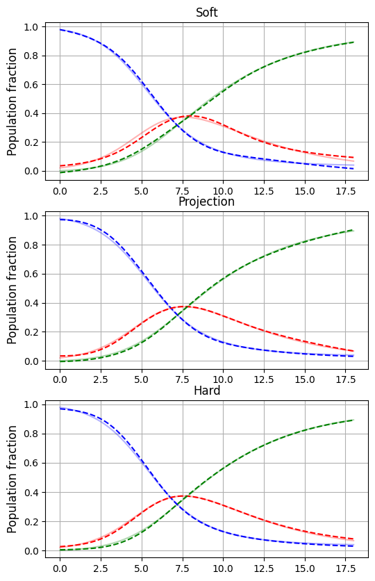

```python
names = ['Soft', 'Projection', 'Hard']
predictions = [P_soft, P_proj, P_hard]

plt.figure(figsize = (6, 10))

for k in range(3):
    plt.subplot(3, 1, k+1)
    plt.plot(t2, Y[:, 0], 'b', t2, Y[:, 1], 'r', t2, Y[:, 2], 'g', alpha = 0.3)
    plt.plot(t2, predictions[k][:, 0], 'b--')
    plt.plot(t2, predictions[k][:, 1], 'r--')
    plt.plot(t2, predictions[k][:, 2], 'g--')
    plt.title(names[k], fontsize = 12)
    plt.ylabel('Population fraction', fontsize = 12)
    plt.grid(True)

plt.show()
```

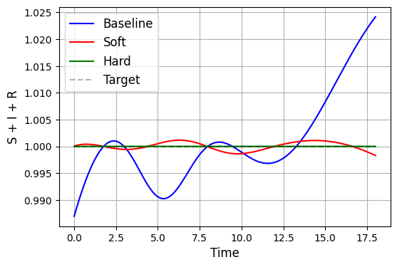

```python
plt.figure(figsize = (6, 4))
plt.plot(t2, np.sum(P_base, 1), 'b')
plt.plot(t2, np.sum(P_soft, 1), 'r')
plt.plot(t2, np.sum(P_hard, 1), 'g')
plt.plot(t2, np.ones(len(t2)), 'k--', alpha = 0.3)
plt.xlabel('Time', fontsize = 12)
plt.ylabel('S + I + R', fontsize = 12)
plt.legend(['Baseline', 'Soft', 'Hard', 'Target'], fontsize = 12)
plt.grid(True)
plt.show()
```

### 2.5.1. Numerical Check

```python
print('model       max |sum - 1|   negative values')

for name, P in [('baseline', P_base), ('soft', P_soft), ('projection', P_proj), ('hard', P_hard)]:
    sum_error = np.max(np.abs(np.sum(P, 1) - 1))
    negative = np.sum(P < 0)

    print('%-11s %13.2e %14d' % (name, sum_error, negative))
```

```
model       max |sum - 1|   negative values
baseline         2.42e-02             10
soft             1.69e-03              9
projection       1.19e-07              9
hard             1.19e-07              0
```

### 2.5.2. Interpretation

- **Soft:** remains close to the conservation target, but small sum or positivity violations can remain.
- **Projection:** corrects the sum exactly after prediction, but does not guarantee nonnegative fractions.
- **Hard:** Softmax guarantees both positivity and unit sum at every time.

> **Key point:** projection is effective for a linear equality, while a suitable output transformation can satisfy multiple compatible constraints at once.

# 3. Pairwise Interaction: Invariance and Equivariance

> **Question:** should the predicted interaction change when the same particle pair is moved, rotated, or reordered?

| Item | Definition |
| --- | --- |
| Input | Two particle coordinates $X=[\mathbf{x}_1,\mathbf{x}_2]$ |
| Output | Interaction energy $U$ |
| Prior knowledge | Translation, rotation, and permutation invariance |
| Derived quantity | Equivariant force $\mathbf F=-\nabla_XU$ |

For this example, energy depends only on pairwise distance:

$$ U(TX)=U(X), \qquad r=\left\|\mathbf{x}_2-\mathbf{x}_1\right\|_2, \qquad U=\frac{1}{r}. $$

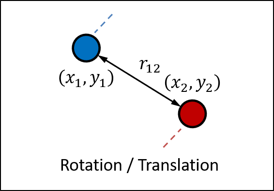

## 3.1. Pairwise Interaction Data

Ninety pairs at distances between $0.7$ and $2$, all in nearly the same orientation and centred near the origin. The narrowness is deliberate: the training data say nothing about rotation or translation, so whatever invariance a model shows must come from where the symmetry was embedded.

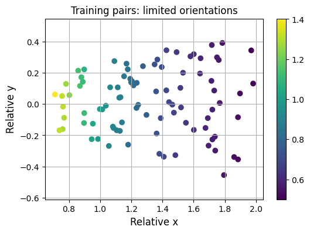

```python
n = 90

r = np.random.uniform(0.7, 2.0, n)             # distance between the two particles
a = np.random.uniform(-0.25, 0.25, n)          # orientation: a narrow range only
cx = np.random.uniform(-0.15, 0.15, n)         # center of the pair
cy = np.random.uniform(-0.15, 0.15, n)

dx = r*np.cos(a)
dy = r*np.sin(a)

X = np.zeros((n, 4))                           # [x1, y1, x2, y2]
X[:, 0] = cx - dx/2
X[:, 1] = cy - dy/2
X[:, 2] = cx + dx/2
X[:, 3] = cy + dy/2

U = (1/r).reshape(-1, 1)                       # interaction energy

plt.figure(figsize = (6, 4))
plt.scatter(X[:, 2] - X[:, 0], X[:, 3] - X[:, 1], c = U[:, 0])
plt.colorbar()
plt.axis('equal')
plt.xlabel('Relative x', fontsize = 12)
plt.ylabel('Relative y', fontsize = 12)
plt.title('Training pairs: limited orientations', fontsize = 12)
plt.grid(True)
plt.show()
```

## 3.2. Four Symmetry Strategies

| Strategy | Where symmetry enters | Expected behavior |
| --- | --- | --- |
| Raw coordinates | Nowhere | Sensitive to representation |
| Data augmentation | Training data | Approximate invariance |
| Augmented + pooling | Output aggregation | More consistent predictions |
| Invariant feature | Model input | Invariance by construction |

Pooling averages predictions over a finite transformation set $G$:

$$ \bar U(X)=\frac{1}{|G|}\sum_{g\in G}f_\theta(gX). $$

It is an inference-time operation, not a separately trained model. By contrast, the invariant-feature model receives only

$$ r=\left\|\mathbf{x}_2-\mathbf{x}_1\right\|_2, $$

which is unchanged by translation, rotation, or particle swapping.

## 3.3. Training the Symmetry Strategies

Three models are trained on the same energies: one on the raw coordinates, one on the pairs rotated, translated and swapped, and one on the distance alone.

```python
# augmented data: each pair is rotated, translated, and sometimes swapped

X_aug = np.zeros((6*n, 4))
U_aug = np.zeros((6*n, 1))

for m in range(6):
    a = np.random.uniform(-np.pi, np.pi)
    sx = np.random.uniform(-2, 2)
    sy = np.random.uniform(-2, 2)

    x1 = np.cos(a)*X[:, 0] - np.sin(a)*X[:, 1] + sx
    y1 = np.sin(a)*X[:, 0] + np.cos(a)*X[:, 1] + sy
    x2 = np.cos(a)*X[:, 2] - np.sin(a)*X[:, 3] + sx
    y2 = np.sin(a)*X[:, 2] + np.cos(a)*X[:, 3] + sy

    rows = np.arange(m*n, (m+1)*n)

    if m % 2 == 0:
        X_aug[rows] = np.column_stack([x1, y1, x2, y2])
    else:
        X_aug[rows] = np.column_stack([x2, y2, x1, y1])   # the two particles are swapped

    U_aug[rows] = U

r_train = np.sqrt((X[:, 2] - X[:, 0])**2 + (X[:, 3] - X[:, 1])**2).reshape(-1, 1)
```

```python
def train(net, inputs, targets):
    xx = torch.tensor(inputs, dtype = torch.float32)
    yy = torch.tensor(targets, dtype = torch.float32)

    optm = torch.optim.Adam(net.parameters(), lr = 0.002)

    for epoch in range(1800):
        loss = torch.mean((net(xx) - yy)**2)

        optm.zero_grad()
        loss.backward()
        optm.step()

    return loss.item()


net_raw = nn.Sequential(nn.Linear(4, 32), nn.Tanh(), nn.Linear(32, 32), nn.Tanh(), nn.Linear(32, 1))
net_aug = nn.Sequential(nn.Linear(4, 32), nn.Tanh(), nn.Linear(32, 32), nn.Tanh(), nn.Linear(32, 1))
net_inv = nn.Sequential(nn.Linear(1, 32), nn.Tanh(), nn.Linear(32, 32), nn.Tanh(), nn.Linear(32, 1))

print('raw       loss = %.3e' % train(net_raw, X, U))
print('augmented loss = %.3e' % train(net_aug, X_aug, U_aug))
print('invariant loss = %.3e' % train(net_inv, r_train, U))
```

```
raw       loss = 4.768e-05
augmented loss = 2.264e-04
invariant loss = 3.663e-06
```

### 3.3.1. Transformation Pooling at Inference

Pooling averages the augmented model's prediction over four rotations and the two particle orderings. It is applied at inference and trains nothing.

```python
def move_pair(Xt, a, swap):
    p = np.zeros(Xt.shape)

    cx = (Xt[:, 0] + Xt[:, 2])/2               # center the pair first
    cy = (Xt[:, 1] + Xt[:, 3])/2

    x1 = Xt[:, 0] - cx
    y1 = Xt[:, 1] - cy
    x2 = Xt[:, 2] - cx
    y2 = Xt[:, 3] - cy

    p[:, 0] = np.cos(a)*x1 - np.sin(a)*y1
    p[:, 1] = np.sin(a)*x1 + np.cos(a)*y1
    p[:, 2] = np.cos(a)*x2 - np.sin(a)*y2
    p[:, 3] = np.sin(a)*x2 + np.cos(a)*y2

    if swap:
        p = p[:, [2, 3, 0, 1]]

    return p


def pool_predict(net, Xt):                     # average over 4 rotations x 2 orderings
    total = np.zeros((len(Xt), 1))

    for a in [0, np.pi/2, np.pi, 3*np.pi/2]:
        for swap in [False, True]:
            p = move_pair(Xt, a, swap)

            with torch.no_grad():
                total = total + net(torch.tensor(p, dtype = torch.float32)).numpy()

    return total/8
```

## 3.4. Equivalent Configurations

One pair at distance $1.2$ is rotated through a full circle, moved along a line and reordered. Every one of these configurations has the same energy, so any variation in a prediction is a failure of invariance.

```python
def predict_all(Xt):
    r = np.sqrt((Xt[:, 2] - Xt[:, 0])**2 + (Xt[:, 3] - Xt[:, 1])**2).reshape(-1, 1)

    with torch.no_grad():
        p_raw = net_raw(torch.tensor(Xt, dtype = torch.float32)).numpy()
        p_aug = net_aug(torch.tensor(Xt, dtype = torch.float32)).numpy()
        p_inv = net_inv(torch.tensor(r, dtype = torch.float32)).numpy()

    p_pool = pool_predict(net_aug, Xt)

    return p_raw[:, 0], p_aug[:, 0], p_pool[:, 0], p_inv[:, 0]


pair = np.array([-0.6, 0.0, 0.6, 0.0])         # the reference pair, distance 1.2
U_ref = 1/1.2

print('reference energy = %.4f' % U_ref)
```

```
reference energy = 0.8333
```

```python
# rotation test: the same pair turned through a full circle

angles = np.linspace(0, 2*np.pi, 121)
X_rot = np.zeros((121, 4))

for k in range(121):
    X_rot[k] = move_pair(pair.reshape(1, 4), angles[k], False)

rot_raw, rot_aug, rot_pool, rot_inv = predict_all(X_rot)

# translation test: the same pair moved along a line

shifts = np.linspace(-2, 2, 121)
X_tr = np.zeros((121, 4))

for k in range(121):
    X_tr[k] = pair + np.array([shifts[k], 0.5*shifts[k], shifts[k], 0.5*shifts[k]])

tr_raw, tr_aug, tr_pool, tr_inv = predict_all(X_tr)

# particle-order test: the same pair with the two particles exchanged

X_sw = np.zeros((2, 4))
X_sw[0] = pair
X_sw[1] = pair[[2, 3, 0, 1]]

sw_raw, sw_aug, sw_pool, sw_inv = predict_all(X_sw)
```

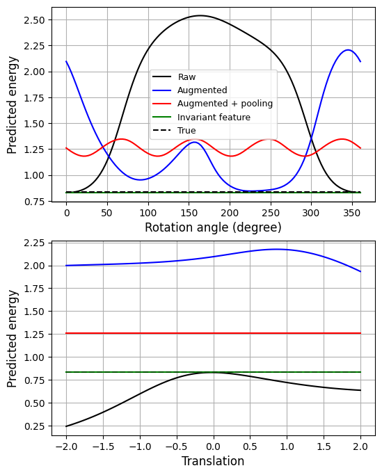

```
method               original   swapped
raw                    0.8298    2.5192
augmented              2.0947    1.0831
augmented + pooling    1.2606    1.2606
invariant feature      0.8318    0.8318
```

```python
plt.figure(figsize = (6, 8))

plt.subplot(2, 1, 1)
plt.plot(angles*180/np.pi, rot_raw, 'k')
plt.plot(angles*180/np.pi, rot_aug, 'b')
plt.plot(angles*180/np.pi, rot_pool, 'r')
plt.plot(angles*180/np.pi, rot_inv, 'g')
plt.plot(angles*180/np.pi, U_ref*np.ones(121), 'k--')
plt.xlabel('Rotation angle (degree)', fontsize = 12)
plt.ylabel('Predicted energy', fontsize = 12)
plt.legend(['Raw', 'Augmented', 'Augmented + pooling', 'Invariant feature', 'True'], fontsize = 9)
plt.grid(True)

plt.subplot(2, 1, 2)
plt.plot(shifts, tr_raw, 'k')
plt.plot(shifts, tr_aug, 'b')
plt.plot(shifts, tr_pool, 'r')
plt.plot(shifts, tr_inv, 'g')
plt.plot(shifts, U_ref*np.ones(121), 'k--', alpha = 0.3)
plt.xlabel('Translation', fontsize = 12)
plt.ylabel('Predicted energy', fontsize = 12)
plt.grid(True)

plt.show()

print('method               original   swapped')
print('raw                 %9.4f %9.4f' % (sw_raw[0], sw_raw[1]))
print('augmented           %9.4f %9.4f' % (sw_aug[0], sw_aug[1]))
print('augmented + pooling %9.4f %9.4f' % (sw_pool[0], sw_pool[1]))
print('invariant feature   %9.4f %9.4f' % (sw_inv[0], sw_inv[1]))
```

### 3.4.1. Interpretation

The reference pair has $r=1.2$, so every equivalent configuration should produce $U=1/1.2\approx0.833$.

| Method | Rotation | Translation | Particle order | What the plots show |
| --- | --- | --- | --- | --- |
| Raw | Sensitive | Sensitive | Sensitive | Coordinate representation changes the prediction |
| Augmented | Approximate | Approximate | Approximate | Additional data reduces but does not eliminate sensitivity |
| Augmented + pooling | Discrete approximation | Exact after centering | Exact after averaging | Consistent output can still be inaccurate |
| Invariant feature | Exact | Exact | Exact | The green prediction overlaps the reference |

> **Key point:** invariance and predictive accuracy are different properties. Pooling can stabilize a biased prediction, while an appropriate invariant feature removes irrelevant variation before learning.

## 3.5. From Invariant Energy to Equivariant Force

Force is obtained from the gradient of the learned scalar energy:

$$ \mathbf F_2=-\nabla_{\mathbf{x}_2}U. $$

If $U$ depends only on invariant distance, rotating the input preserves energy and rotates the force in the same way:

$$ U(RX)=U(X), \qquad \mathbf F(RX)=R\mathbf F(X). $$

The check is numerical: the pair is rotated, and the force predicted for the rotated pair is compared with the rotated force of the original. It verifies the **equivariance structure**, not the physical accuracy of the force magnitude.

```
energy before rotation = 0.831822
energy after  rotation = 0.831822
error between the rotated force and the predicted force = 1.94e-08
```

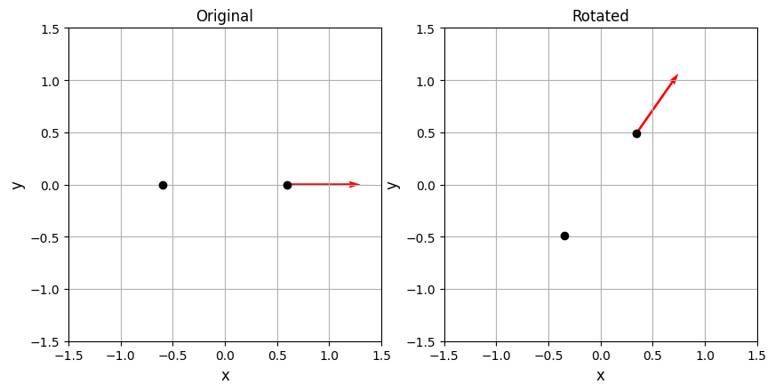

```python
def energy_and_force(net, p):
    q = torch.tensor(p.reshape(1, 4), dtype = torch.float32, requires_grad = True)

    r = torch.sqrt((q[:, 2] - q[:, 0])**2 + (q[:, 3] - q[:, 1])**2).reshape(1, 1)
    energy = net(r)

    gradient = torch.autograd.grad(energy, q)[0]
    force = -gradient[0, 2:].numpy()           # force acting on particle 2

    return energy.item(), force


a = 55*np.pi/180                               # rotate the pair by 55 degrees

pair_rot = np.zeros(4)
pair_rot[0] = np.cos(a)*pair[0] - np.sin(a)*pair[1]
pair_rot[1] = np.sin(a)*pair[0] + np.cos(a)*pair[1]
pair_rot[2] = np.cos(a)*pair[2] - np.sin(a)*pair[3]
pair_rot[3] = np.sin(a)*pair[2] + np.cos(a)*pair[3]

U1, F1 = energy_and_force(net_inv, pair)
U2, F2 = energy_and_force(net_inv, pair_rot)

# the force of the original pair, rotated by the same angle
F1_rot = np.array([np.cos(a)*F1[0] - np.sin(a)*F1[1],
                   np.sin(a)*F1[0] + np.cos(a)*F1[1]])

print('energy before rotation = %.6f' % U1)
print('energy after  rotation = %.6f' % U2)
print('error between the rotated force and the predicted force = %.2e' % np.linalg.norm(F2 - F1_rot))

plt.figure(figsize = (10, 5))

plt.subplot(1, 2, 1)
plt.plot([pair[0], pair[2]], [pair[1], pair[3]], 'ko')
plt.quiver(pair[2], pair[3], F1[0], F1[1], angles = 'xy', scale_units = 'xy', scale = 1, color = 'r')
plt.gca().set_aspect('equal')
plt.xlim(-1.5, 1.5)
plt.ylim(-1.5, 1.5)
plt.title('Original', fontsize = 12)
plt.xlabel('x', fontsize = 12)
plt.ylabel('y', fontsize = 12)
plt.grid(True)

plt.subplot(1, 2, 2)
plt.plot([pair_rot[0], pair_rot[2]], [pair_rot[1], pair_rot[3]], 'ko')
plt.quiver(pair_rot[2], pair_rot[3], F2[0], F2[1], angles = 'xy', scale_units = 'xy', scale = 1, color = 'r')
plt.gca().set_aspect('equal')
plt.xlim(-1.5, 1.5)
plt.ylim(-1.5, 1.5)
plt.title('Rotated', fontsize = 12)
plt.xlabel('x', fontsize = 12)
plt.ylabel('y', fontsize = 12)
plt.grid(True)

plt.show()
```

### 3.5.1. Interpretation

- The energy is unchanged before and after rotation.
- The force arrow rotates with the particle pair.
- The small rotated-force error confirms $\mathbf F(RX)\approx R\mathbf F(X)$.

> **Key point:** an invariant scalar potential can generate an equivariant vector field through automatic differentiation.

# Summary

**Key takeaways**

- Prior knowledge can enter a network at six places, the data, the input features, the loss, the output transformation, the post-processing and the differentiation, and the three labs used all of them.
- A loss penalty discourages a violation but does not forbid it; an output transformation or a projection makes the constraint exact by construction, and the two can be combined when a quantity must satisfy several conditions at once.
- Symmetry is cheapest to enforce early: a distance feature removes the irrelevant coordinates before the network sees them, whereas augmentation only teaches the symmetry approximately and pooling has to correct for it afterwards.

**Where was prior knowledge embedded?**

| Pipeline location | Example in the labs | Effect |
| --- | --- | --- |
| Data | Rotated, translated, and swapped particle pairs | Symmetry learned approximately |
| Input feature | Pairwise distance | Irrelevant coordinates removed |
| Loss | Positivity, monotonicity, IC, conservation, smoothness | Violations discouraged |
| Output transformation | Cumulative exponential and Softmax | Constraints exact by construction |
| Post-processing | Projection and transformation pooling | Output corrected or symmetrized |
| Differentiation | Force from invariant energy | Equivariant vector output |

> **Design rule:** enforce what must hold, penalize what should hold, and encode symmetry as early as practical.

**Looking ahead.** Every constraint in these labs was a statement about the output, a sign, a monotone trend, a sum, a symmetry. The next notebook, **Physics-informed Neural Networks (PINN)**, adds the strongest prior of all, the governing differential equation itself, and puts it into the loss through the same mechanism used here for the penalties, with the output transformations of Lab 1 reappearing as the hard constraints of a PINN.